# Final

El dataset contiene 1728 observaciones en las siguientes 7 variables, donde cada fila contiene información sobre un automóvil. Todas las variables son variables categoricas.

buying Buying price of the car (Levels: high, low, med ,vhigh)

maint Price of the maintenance (Levels: high, low, med, vhigh)

doors Number of doors (Levels: 2, 3, 4, 5more)

persons Capacity in terms of persons to carry (Levels: 2, 4, more)

lug_boot Size of luggage boot (Levels: big, med, small)

safety Estimated safety of the car (Levels: high, low, med)

acceptance Acceptance of the car (target variable) (Levels: acc, good, unacc, vgood)

```r
car.dataset <- read.csv(url("http://archive.ics.uci.edu/ml/machine-learning-databases/car/car.data"), header=FALSE, col.names = c("buying","maint","doors","persons","lug_boot", "safety", "acceptance"))
str(car.dataset)
```

```
## 'data.frame':    1728 obs. of  7 variables:
##  $ buying    : Factor w/ 4 levels "high","low","med",..: 4 4 4 4 4 4 4 4 4 4 ...
##  $ maint     : Factor w/ 4 levels "high","low","med",..: 4 4 4 4 4 4 4 4 4 4 ...
##  $ doors     : Factor w/ 4 levels "2","3","4","5more": 1 1 1 1 1 1 1 1 1 1 ...
##  $ persons   : Factor w/ 3 levels "2","4","more": 1 1 1 1 1 1 1 1 1 2 ...
##  $ lug_boot  : Factor w/ 3 levels "big","med","small": 3 3 3 2 2 2 1 1 1 3 ...
##  $ safety    : Factor w/ 3 levels "high","low","med": 2 3 1 2 3 1 2 3 1 2 ...
##  $ acceptance: Factor w/ 4 levels "acc","good","unacc",..: 3 3 3 3 3 3 3 3 3 3 ...
```

En el siguiente gráfico se muestran los items con una frecuencia de más de 0.1 (soporte > 0.1). En este gráfico podemos decidir qué items estudiar más en profundidad. Para obtener reglas con valor, podemos analizar reglas en las que aparezcan items no muy frecuentes. Como se muestra, hay algunos items bastante frecuentes, como son por ejemplo “acceptance=unacc”. Sin embargo, estudiar los items opuestos puede resultar bastante más interesante.

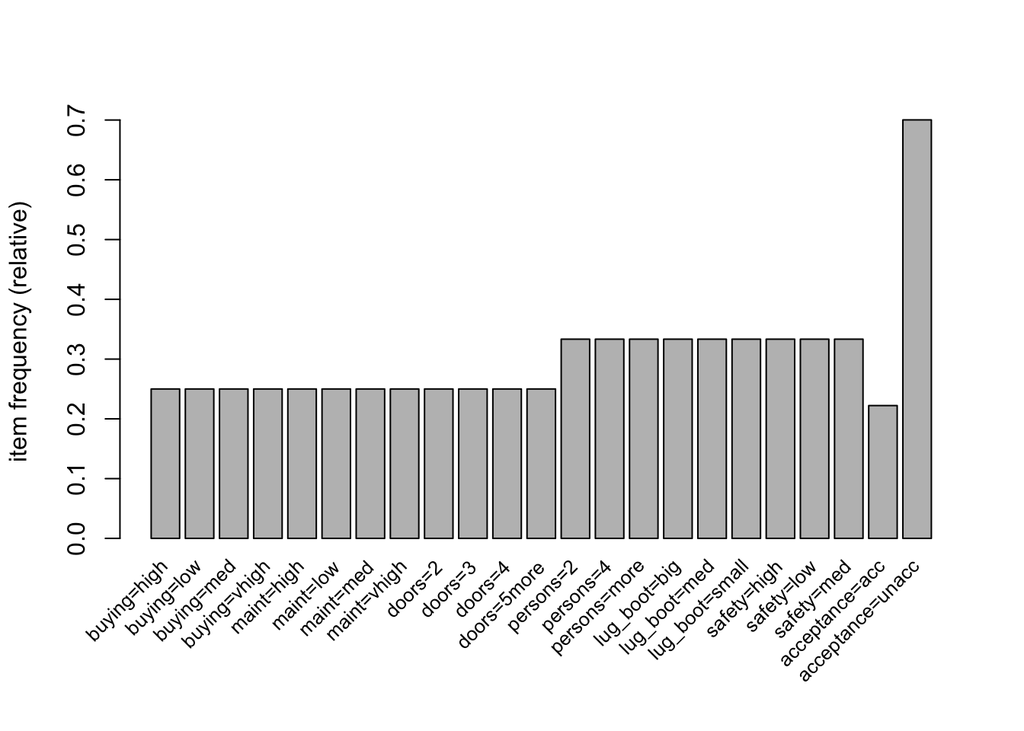

```r
car.transactions <- as(car.dataset,"transactions")
itemFrequencyPlot(car.transactions, support=0.1, cex.names=0.8)
```

A continuación usamos apriori con un soporte mínimo de 0.1 para obtener los itemsets frecuentees.Primera información importante que acceptance=unacc es muy frecuente. En el barplot se muestran los tamaños de itemsets frecuentes. Se ve cómo el tamaño de itemsets más frecuente es 2.

```r
car.rules <- apriori(car.transactions, parameter=list(support=0.1,target="frequent"))
```

```
## Apriori
##
## Parameter specification:
##  confidence minval smax arem  aval originalSupport maxtime support minlen
##          NA    0.1    1 none FALSE            TRUE       5     0.1      1
##  maxlen            target   ext
##      10 frequent itemsets FALSE
##
## Algorithmic control:
##  filter tree heap memopt load sort verbose
##     0.1 TRUE TRUE  FALSE TRUE    2    TRUE
##
## Absolute minimum support count: 172
##
## set item appearances ...[0 item(s)] done [0.00s].
## set transactions ...[25 item(s), 1728 transaction(s)] done [0.00s].
## sorting and recoding items ... [23 item(s)] done [0.00s].
## creating transaction tree ... done [0.00s].
## checking subsets of size 1 2 3 done [0.00s].
## writing ... [86 set(s)] done [0.00s].
## creating S4 object  ... done [0.00s].
```

```r
car.rules.sorted <- sort(car.rules, by="support")
```

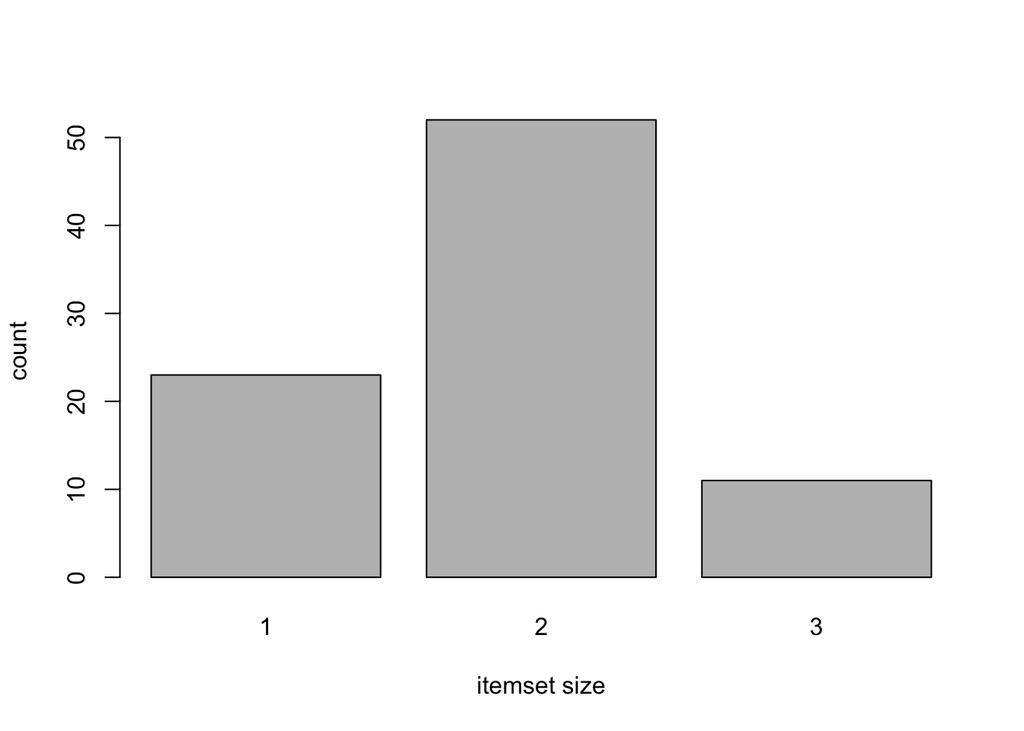

```r
barplot(table(size(car.rules)), xlab="itemset size", ylab="count")
```

```r
inspect(car.rules)
```

```
##      items                                        support   count
## [1]  {acceptance=acc}                             0.2222222  384
## [2]  {buying=med}                                 0.2500000  432
## [3]  {buying=high}                                0.2500000  432
## [4]  {maint=low}                                  0.2500000  432
## [5]  {buying=vhigh}                               0.2500000  432
## [6]  {maint=med}                                  0.2500000  432
## [7]  {maint=high}                                 0.2500000  432
## [8]  {doors=5more}                                0.2500000  432
## [9]  {doors=4}                                    0.2500000  432
## [10] {doors=3}                                    0.2500000  432
## [11] {doors=2}                                    0.2500000  432
## [12] {maint=vhigh}                                0.2500000  432
## [13] {buying=low}                                 0.2500000  432
## [14] {lug_boot=big}                               0.3333333  576
```

[output cut: 72 more lines]

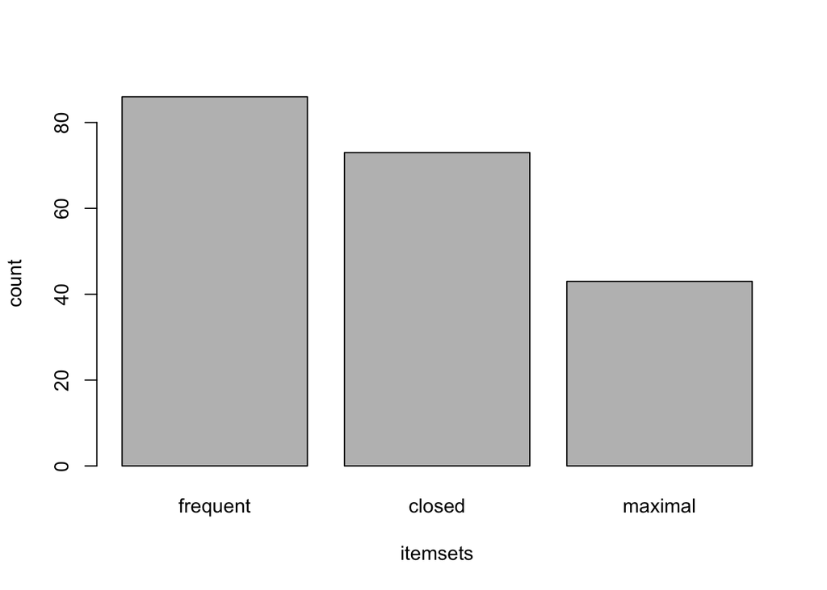

```r
car.rules.maximal <- car.rules[is.maximal(car.rules)]
#inspect(head(sort(car.rules.maximal, by="support")))
car.rules.closed <- car.rules[is.closed(car.rules)]
#inspect(head(sort(car.rules.closed, by="support")))
barplot( c(frequent=length(car.rules), closed=length(car.rules.closed), maximal=length(car.rules.maximal)), ylab="count", xlab="itemsets")
```

** Reglas general

A continuación empezamos ya a aplicar apriori para la obtención de reglas. En esta ejecución indicaré que el mínimo soporte sea de 0.09 y la mínima confianza de 0.75. También indicaré el mínimo del tamaño de las reglas, que será 2.

```r
car.rules <- apriori(car.transactions, parameter = list(minlen=2, supp=0.09, conf=0.75))
```

```
## Apriori
##
## Parameter specification:
##  confidence minval smax arem  aval originalSupport maxtime support minlen
##        0.75    0.1    1 none FALSE            TRUE       5    0.09      2
##  maxlen target   ext
##      10  rules FALSE
##
## Algorithmic control:
##  filter tree heap memopt load sort verbose
##     0.1 TRUE TRUE  FALSE TRUE    2    TRUE
##
## Absolute minimum support count: 155
##
## set item appearances ...[0 item(s)] done [0.00s].
## set transactions ...[25 item(s), 1728 transaction(s)] done [0.00s].
## sorting and recoding items ... [23 item(s)] done [0.00s].
## creating transaction tree ... done [0.00s].
## checking subsets of size 1 2 3 done [0.00s].
## writing ... [19 rule(s)] done [0.00s].
## creating S4 object  ... done [0.00s].
```

```r
quality(car.rules) <- cbind(quality(car.rules), interestMeasure(car.rules, c("chiSquare", "conviction", "cosine", "coverage", "leverage", "oddsRatio"), car.dataset))
car.rules.sorted <- sort(car.rules, by="support")
inspect(car.rules.sorted)
```

```
##      lhs                            rhs                support
## [1]  {safety=low}                => {acceptance=unacc} 0.33333333
## [2]  {persons=2}                 => {acceptance=unacc} 0.33333333
## [3]  {lug_boot=small}            => {acceptance=unacc} 0.26041667
## [4]  {buying=vhigh}              => {acceptance=unacc} 0.20833333
## [5]  {maint=vhigh}               => {acceptance=unacc} 0.20833333
## [6]  {doors=2}                   => {acceptance=unacc} 0.18865741
## [7]  {buying=high}               => {acceptance=unacc} 0.18750000
## [8]  {lug_boot=big,safety=low}   => {acceptance=unacc} 0.11111111
## [9]  {persons=2,lug_boot=big}    => {acceptance=unacc} 0.11111111
## [10] {persons=4,safety=low}      => {acceptance=unacc} 0.11111111
## [11] {persons=more,safety=low}   => {acceptance=unacc} 0.11111111
## [12] {lug_boot=med,safety=low}   => {acceptance=unacc} 0.11111111
## [13] {persons=2,lug_boot=med}    => {acceptance=unacc} 0.11111111
## [14] {persons=2,safety=high}     => {acceptance=unacc} 0.11111111
```

[output cut: 45 more lines]

En las anteriores reglas se ve cómo la principal consecuencia que nos permite tener un lift bueno es acceptance=unacc. Las dos primeras reglas nos proporcionan gran cantidad de información, puesto que nos indican que en un 33% (soporte=0.33) de los casos de nuestro dataset la compra de dicho coche será inaceptable en caso de que la seguridad proporcionada por este sea baja o el número de pasajeros sea 2 (es el mínimo). Esto nos indica que, en general, segun nuestro dataset aquellos coches que cumplan alguna o ambas de estas reglas seran, probablemente, inaceptables.

```
## To reduce overplotting, jitter is added! Use jitter = 0 to prevent jitter.
```

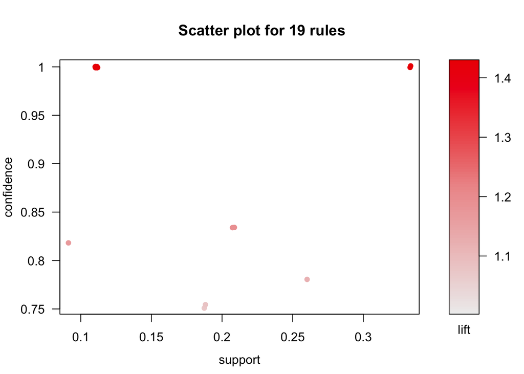

```r
plot(car.rules)
```

[output not shown]

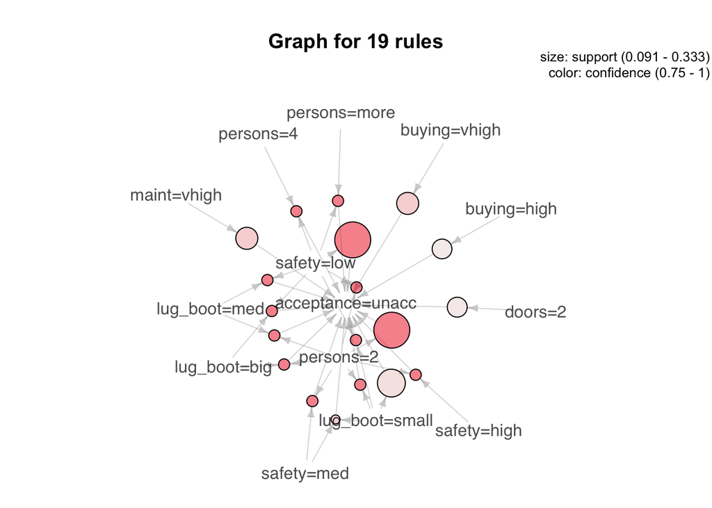

```r
plot(car.rules, method="graph", control=list(type="items"), measure='support', shading='confidence')
```

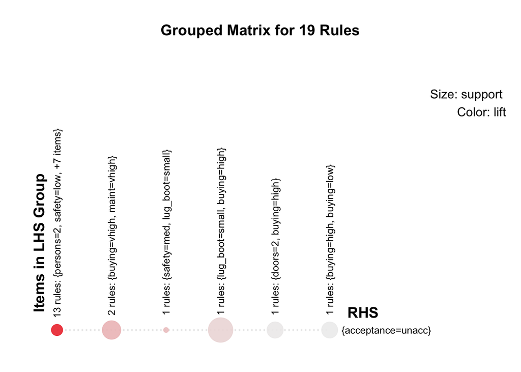

```r
plot(car.rules, method="grouped")
```

A partir de las reglas de asociación nos queda claro que las variables mas importantes para evaluar un coche son el numero de pasajeros y la seguridad. Si alguna de estas variables es “mala”, entonces el coche no sera aceptable.

** Reglas específicas mediante filtrado

```r
deleteRebundantRules <- function (rules) {
  subsetMatrix <- is.subset(rules, rules)
  subsetMatrix[lower.tri(subsetMatrix, diag=TRUE)] <- FALSE
  redundant <- colSums(subsetMatrix, na.rm=TRUE) >= 1
  rules <- rules[!redundant]
  return (rules)
}
```

Una vez ya tenemos todas las reglas, vamos a ver qué reglas nos pueden parecer interesantes.

Por ejemplo, vamos a agrupar acceptance en acc y unacc, es decir, tanto l os valores de good como vgood se juntarán dentro de acc para que esta variable tenga más presencia en el dataset, y poder observar posibles reglas que nos den indicios de cuando un coche es acceptable. Por lo tanto, hay que realizar un filtrado más específico y evitar que 2 o más items redundantes aparezcan en la misma regla.

```r
car.dataset <- car.dataset
car.dataset$acceptance <- as.factor(ifelse(car.dataset$acceptance %in% c("good","acc","vgood"), "acc", "unacc"))
str(car.dataset)
```

```
## 'data.frame':    1728 obs. of  7 variables:
##  $ buying    : Factor w/ 4 levels "high","low","med",..: 4 4 4 4 4 4 4 4 4 4 ...
##  $ maint     : Factor w/ 4 levels "high","low","med",..: 4 4 4 4 4 4 4 4 4 4 ...
##  $ doors     : Factor w/ 4 levels "2","3","4","5more": 1 1 1 1 1 1 1 1 1 1 ...
##  $ persons   : Factor w/ 3 levels "2","4","more": 1 1 1 1 1 1 1 1 1 2 ...
##  $ lug_boot  : Factor w/ 3 levels "big","med","small": 3 3 3 2 2 2 1 1 1 3 ...
##  $ safety    : Factor w/ 3 levels "high","low","med": 2 3 1 2 3 1 2 3 1 2 ...
##  $ acceptance: Factor w/ 2 levels "acc","unacc": 2 2 2 2 2 2 2 2 2 2 ...
```

```r
car.transactions <- as(car.dataset,"transactions")
car.rules <- apriori(car.transactions, parameter = list(minlen=3, supp=0.09, conf=0.75))
```

```
## Apriori
##
## Parameter specification:
##  confidence minval smax arem  aval originalSupport maxtime support minlen
##        0.75    0.1    1 none FALSE            TRUE       5    0.09      3
##  maxlen target   ext
##      10  rules FALSE
##
## Algorithmic control:
##  filter tree heap memopt load sort verbose
##     0.1 TRUE TRUE  FALSE TRUE    2    TRUE
##
## Absolute minimum support count: 155
##
## set item appearances ...[0 item(s)] done [0.00s].
## set transactions ...[23 item(s), 1728 transaction(s)] done [0.00s].
## sorting and recoding items ... [23 item(s)] done [0.00s].
## creating transaction tree ... done [0.00s].
## checking subsets of size 1 2 3 done [0.00s].
## writing ... [13 rule(s)] done [0.00s].
## creating S4 object  ... done [0.00s].
```

```r
quality(car.rules) <- cbind(quality(car.rules), interestMeasure(car.rules, c("chiSquare", "conviction", "cosine", "coverage", "leverage", "oddsRatio"), car.dataset))
car.rules <- deleteRebundantRules(car.rules)
car.rules.sorted <- sort(car.rules, by="support")
inspect(car.rules.sorted)
```

```
##      lhs                            rhs                support
## [1]  {lug_boot=med,safety=low}   => {acceptance=unacc} 0.11111111
## [2]  {persons=2,lug_boot=med}    => {acceptance=unacc} 0.11111111
## [3]  {lug_boot=big,safety=low}   => {acceptance=unacc} 0.11111111
## [4]  {persons=2,lug_boot=big}    => {acceptance=unacc} 0.11111111
## [5]  {persons=4,safety=low}      => {acceptance=unacc} 0.11111111
## [6]  {persons=more,safety=low}   => {acceptance=unacc} 0.11111111
## [7]  {persons=2,safety=high}     => {acceptance=unacc} 0.11111111
## [8]  {persons=2,safety=med}      => {acceptance=unacc} 0.11111111
## [9]  {lug_boot=small,safety=low} => {acceptance=unacc} 0.11111111
## [10] {persons=2,safety=low}      => {acceptance=unacc} 0.11111111
## [11] {persons=2,lug_boot=small}  => {acceptance=unacc} 0.11111111
## [12] {lug_boot=small,safety=med} => {acceptance=unacc} 0.09085648
## [13] {persons=4,safety=high}     => {acceptance=acc}   0.09027778
##      confidence lift     count chiSquared conviction cosine    coverage
```

[output cut: 27 more lines]

```r
rulesRaceWhite <- subset(car.rules, subset = rhs %in% "persons=2")
inspect(head(rulesRaceWhite))
```

De las anteriores reglas se pueden sacar algunas conclusiones y además a partir de reglas con un Lift bueno. Para mí la más significativa es que independientemente de la seguridad del coche, si el número de pasajeros no es superior a 2, el coche será inaceptable.

{persons=2,safety=high} => {acceptance=unacc} {persons=2,safety=med} => {acceptance=unacc} {persons=2,safety=low} => {acceptance=unacc}